# Project 1

MLB Analysis

Keagan Benson

#Step 1 In this project, I want to understand how the amount of years in the MLB affects the players salary. I also want to know what years the players make the most money on average and what the distribution of both salary and years are.

```r
# Import data
data <- read.csv("mlb.csv", header=T)
```

Next I decided to create two variables, years and salary which contain all the data from both the salary and years data table. Years will be my independent variable and Salary will be my dependent variable because I want to know how the amount of years affects salary. Both of these variables contain discrete and integer values.

```r
years <- data$years
salary <- data$salary
typeof(years)
```

```
## [1] "integer"
```

```r
typeof(salary)
```

```
## [1] "integer"
```

#Step 2 Next I wanted to do some initial data analysis. First I decided to look at a summary of the data. This allows me to briefly check for outliers as well as none types.

```r
summary(data)
```

```
##      salary            years             bavg        gamesyr
##  Min.   : 109000   Min.   : 1.000   Min.   :111   Min.   :  5.50
##  1st Qu.: 253600   1st Qu.: 3.000   1st Qu.:245   1st Qu.: 65.00
##  Median : 675000   Median : 6.000   Median :259   Median : 94.67
##  Mean   :1345672   Mean   : 6.326   Mean   :259   Mean   : 90.08
##  3rd Qu.:2250000   3rd Qu.: 9.000   3rd Qu.:275   3rd Qu.:117.00
##  Max.   :6329213   Max.   :20.000   Max.   :625   Max.   :159.00
##      hrnsyr           rbisyr
##  Min.   : 0.000   Min.   : 0.50
##  1st Qu.: 1.700   1st Qu.:17.67
##  Median : 5.167   Median :31.40
##  Mean   : 7.119   Mean   :35.05
##  3rd Qu.:10.333   3rd Qu.:48.22
##  Max.   :31.429   Max.   :97.62
```

Based on the summary is looks like there are no none types or outliars but I will use other tests to check for outliars.

Next I decided to plot years against salary to check for outliers, as well as compute the z-score and check for outliers that way.

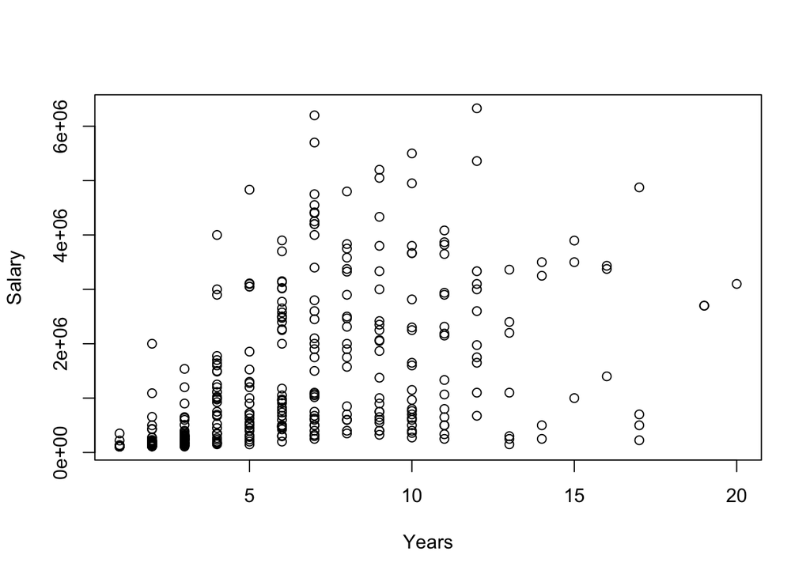

```r
plot(years,salary, xlab = "Years", ylab = "Salary")
```

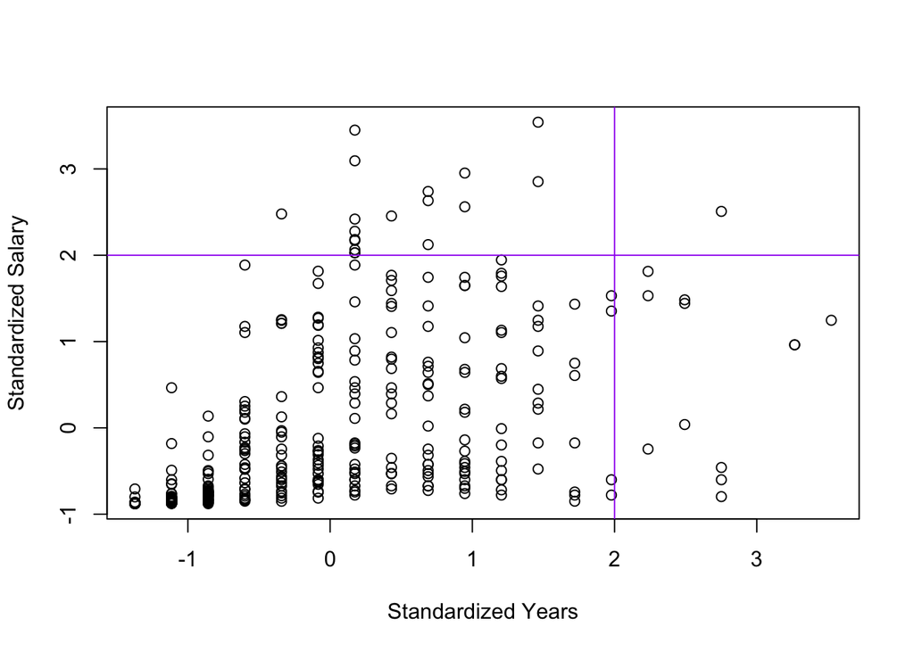

```r
mean_years = mean(years)
mean_salary = mean(salary)
sd_years = sd(years)
sd_salary = sd(salary)
z_score_years = (years - mean_years)/ sd_years
z_score_salary = (salary - mean_salary)/ sd_salary
plot(z_score_years, z_score_salary, xlab = "Standardized Years", ylab = "Standardized Salary")
abline(v=2, col="purple")
abline(h=2, col="purple")
```

After looking at the graph, I believe that the points that are considered outliers by using the z-scores are important for the data set. These points are real salaries and years and should be included in the analysis despite being labeled outliers when they are standardized. Due to the fact that I do not want to exclude outliers and there are none types in the data, the data does not need to be cleaned.

#Step 3 Next I want to look at the distribution of both salaries and years

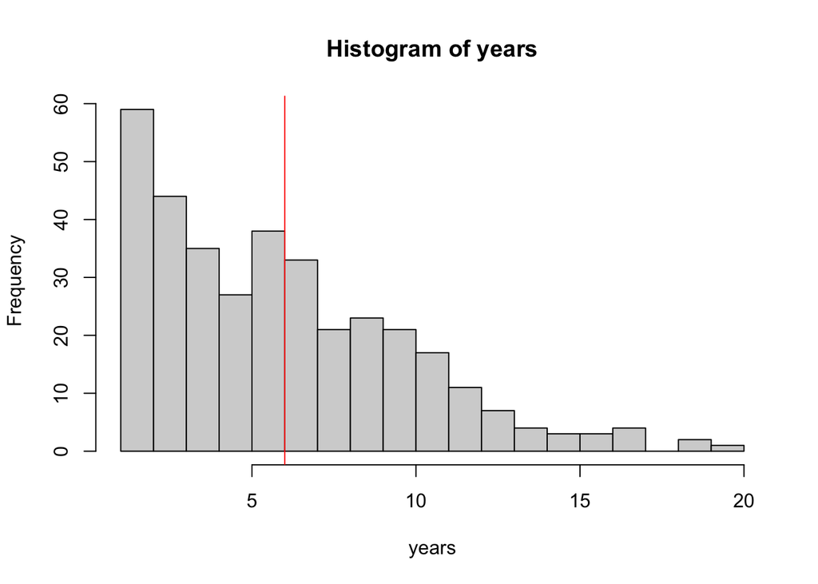

```r
hist(years, breaks = max(years))
abline(v = median(years),col = "red")
```

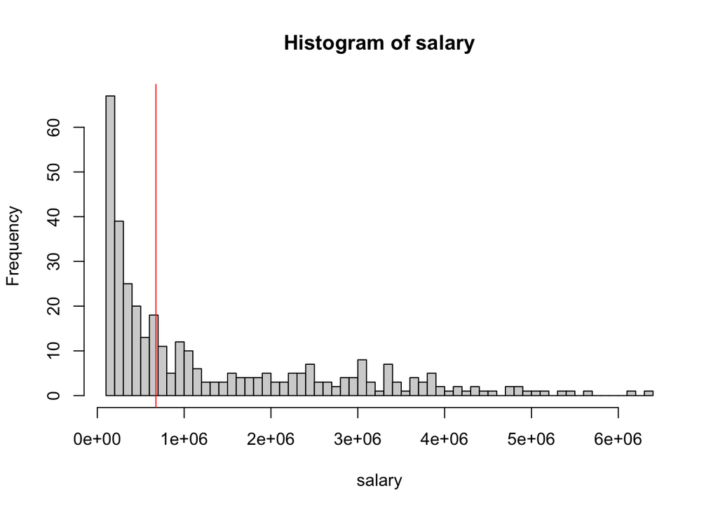

```r
hist(salary, breaks = max(salary)/100000)
abline(v = median(salary), col = "red")
```

#Step 4 Now I want to check the linear regression of the two data frames.

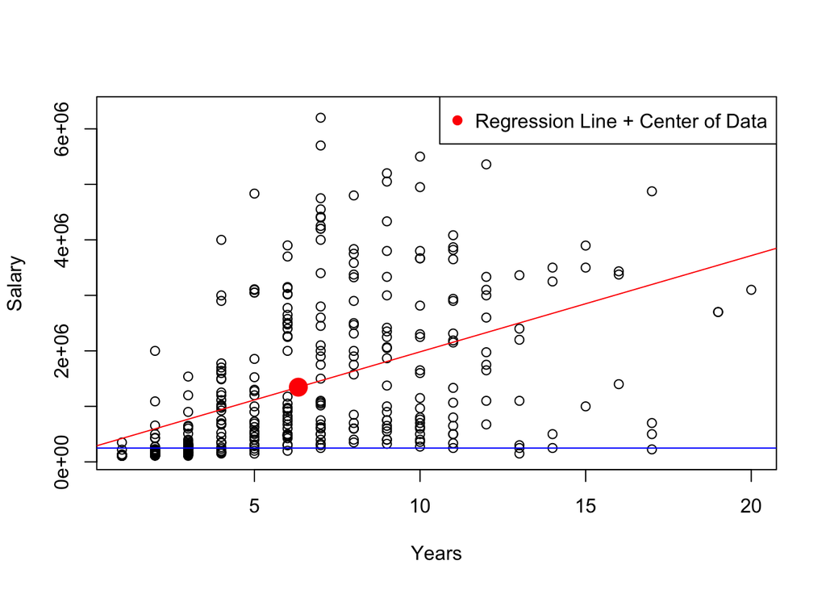

```r
r = cor(years, salary)
a = r*sd_salary/sd_years
b = mean_salary- a*mean_years
plot(years,salary, xlab = "Years", ylab = "Salary")
points(mean_years,mean_salary, col = "red", pch = 19, cex = 2)
abline(b,a, col = "red", lwd = 1)
abline(h = b, col = "blue")
legend("topright", c("Regression Line + Center of Data"), col = "red", pch = 19)
```

```r
paste("y = ",toString(as.integer(a)),"x + ",toString(as.integer(b)), sep = "")
```

```
## [1] "y = 173428x + 248601"
```

```r
r
```

```
## [1] 0.4781517
```

I have plotted the linear regression model on top of the data. I do not believe this a good representation of the data because I do not think that this is data should be represented with a linear model. The model is “y = 173428x + 248601” with a correlation of 0.478. This correlation signals that there is some relationship, but there is not much. Most people aim for 0.8. Another reason I believe this model is poor is that there is a significant amount of salaries that are less than the y intercept, which does not make that much sense because with according to the model, a player with zero years of experience should be making more than a lot of players. #Step 5

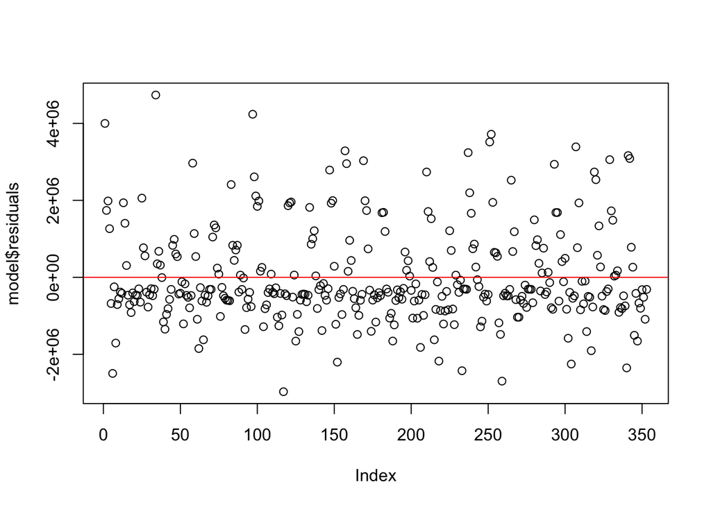

```r
model <- lm(salary ~ years)
plot(model$residuals)
abline(h=0,col = "red")
```

I decided to next check the residuals, and they showed that a lot of the data points are under the regression line, but the regression line is brought upwards by large values. This is because the data is right skewed, and there are a lot of outliers that are on the higher end. This allows me to make the assumption that the mean value is higher than the median.

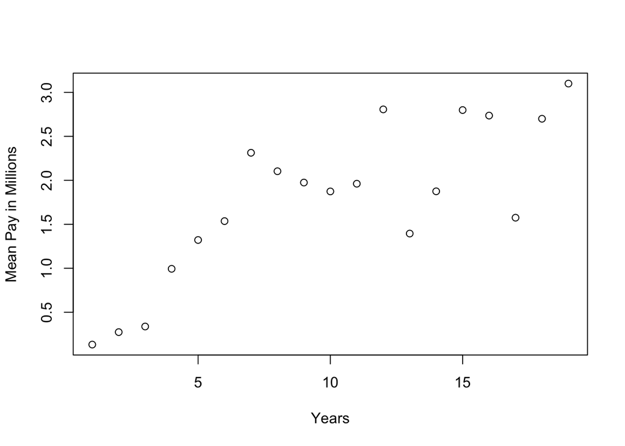

```r
plot(by(salary/1000000, years, mean), xlab = "Years", ylab = "Mean Pay in Millions")
```

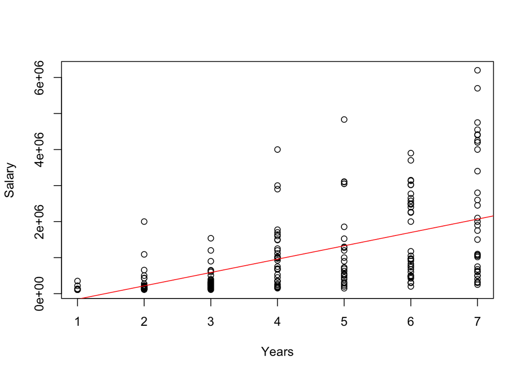

```r
first_seven = data[data$years<8,]

first_seven_years <- first_seven$years
first_seven_salary <- first_seven$salary

first_seven_years_mean <- mean(first_seven_years)
first_seven_salary_mean <- mean(first_seven_salary)
first_seven_years_sd <- sd(first_seven_years)
first_seven_salary_sd <- sd(first_seven_salary)

first_seven_r = cor(first_seven_years, first_seven_salary)
first_seven_m = first_seven_r* first_seven_salary_sd / first_seven_years_sd
first_seven_b = first_seven_salary_mean - first_seven_m * first_seven_years_mean
plot(first_seven_years,first_seven_salary, xlab = "Years", ylab = "Salary")
abline(first_seven_b,first_seven_m, col = "red", lwd = 1)
```

```r
paste("y = ",toString(as.integer(first_seven_m)),"x + ",toString(as.integer(first_seven_b)), sep = "")
```

```
## [1] "y = 370754x + -524712"
```

```r
first_seven_r
```

```
## [1] 0.5808731
```

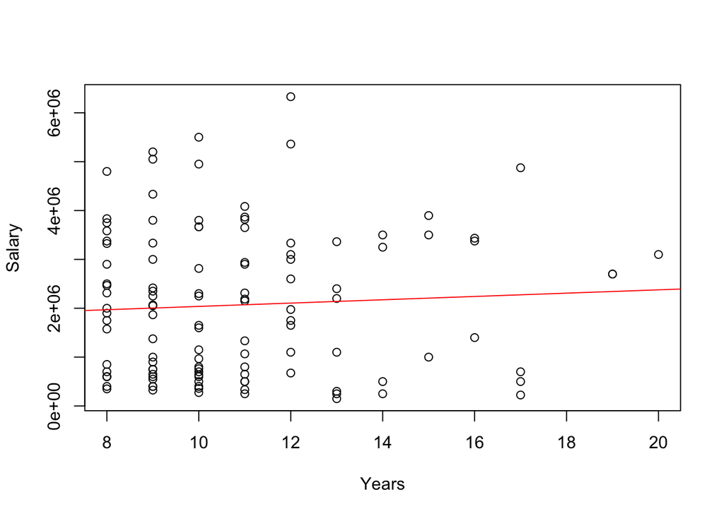

```r
last_seven = data[data$years>7,]

last_seven_years <- last_seven$years
last_seven_salary <- last_seven$salary

last_seven_years_mean <- mean(last_seven_years)
last_seven_salary_mean <- mean(last_seven_salary)
last_seven_years_sd <- sd(last_seven_years)
last_seven_salary_sd <- sd(last_seven_salary)

last_seven_r = cor(last_seven_years, last_seven_salary)
last_seven_m = last_seven_r* last_seven_salary_sd / last_seven_years_sd
last_seven_b = last_seven_salary_mean - last_seven_m * last_seven_years_mean
plot(last_seven_years,last_seven_salary, xlab = "Years", ylab = "Salary")
abline(last_seven_b,last_seven_m, col = "red", lwd = 1)
```

```r
paste("y = ",toString(as.integer(last_seven_m)),"x + ",toString(as.integer(last_seven_b)), sep = "")
```

```
## [1] "y = 33944x + 1698366"
```

```r
last_seven_r
```

```
## [1] 0.06186734
```

#Step 6 Finally I decided to break the data in to 2 different sets based on what I learned by looking at the average salary at every year. So I created one data set where the players had less than 8 years of experience and one with more than 7 years of experience. This allowed me to learn that their is nearly no relationship between a players experience and their salary after their seventh year, but there is a pretty strong relationship between their salary and their experience in their first seven years. This makes since as players should be getting paid more as they get more experience, yet once they hit a certain age some players begin to get worse while some players continue to get better or stay the same. The correlation also should get weaker because their is less data as the years of experience increase. I think that the correlation of almost 0.6 is pretty good considering I am only using linear regression. It is really hard to predict salary given experience because there are so many more variables that result in salary than just experience. I think it is very interesting that experience can be used as a predictor when the player has relatively little experience but as the player plays longer, it is harder to predict.